# Traitement des séquences en ASV

## DADA2

[Pipeline DADA2](https://benjjneb.github.io/dada2/tutorial.html)  
[Pipeline DADA2 modifié](https://doi.org/10.12688/f1000research.8986.2)

```r
library(dada2)
```

### Traitement des raws

Créer un dossier sur le serveur dans lequel vont étre réalisé les annalyses. Ce dossier doit lui même contenir un dossier **fasta** contenant les raw.

On extrait les séquences et on séparent les séquences Forward et Reverse en se basant sur le nom des raws. R1 = Forward, R2 = Reverse.

**ATTENTION** - Changer manuellement le directory pour fast tree

```r
path <- "~/TestBac" #nom du dossier principal, doit contenir un dossier "fasta" contenant les raw

fnFs <- sort(list.files(file.path(path,"fasta"),pattern="_R1_001.fastq", full.names = TRUE))
fnRs <- sort(list.files(file.path(path,"fasta"),pattern="_R2_001.fastq", full.names = TRUE))
```

On extrait le nom des échantillons en se basant sur le modéle: “SAMPLENAME_XXX.fastq”.

**R1 = Forward**  
**R2 = Reverse**

On réalise un graphique de la qualiées des séquences Forward et Reverse. Ce graphique permet d’observer la qualitée du séquençage sur l’ensembles des séquences. Généralement les séquences Reverse sont de moins bonne qualitée sur la fin. On peut ensuite choisir de retirer les derniers nucléotides si la qualitée est mauvaise.

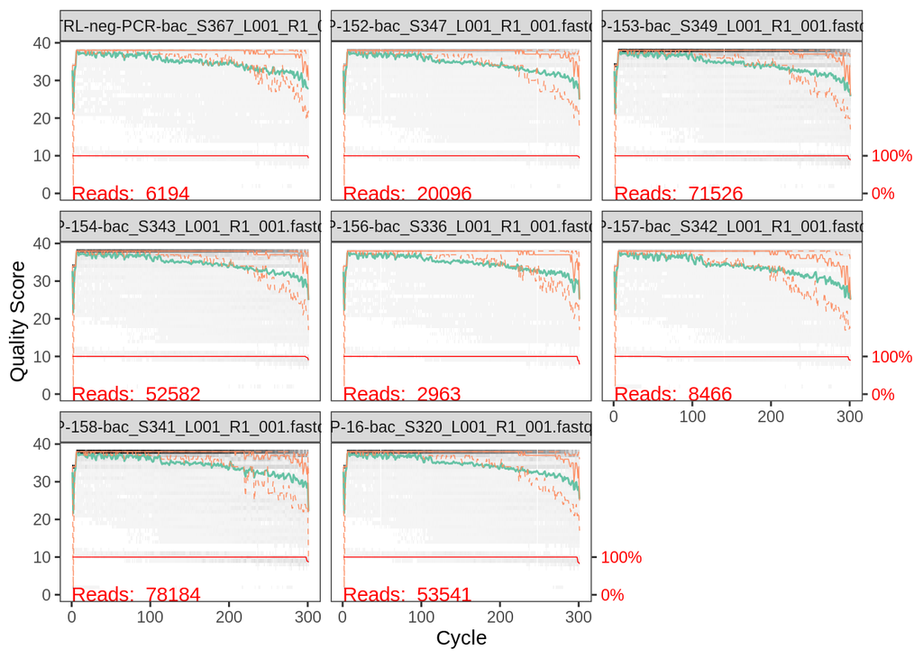

```r
sample.names <- sapply(strsplit(basename(fnFs), "_"), `[`, 1)

plotQualityProfile(fnFs[1:9])
```

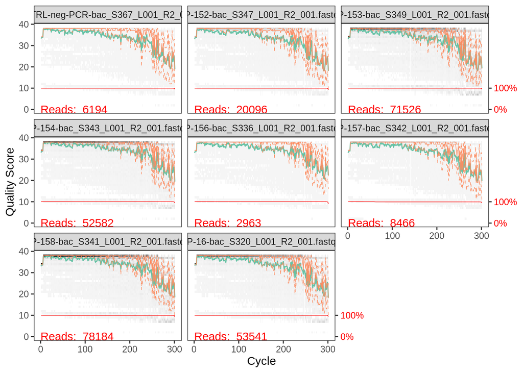

```r
plotQualityProfile(fnRs[1:9])
```

On observe que les séquences forward présentes une faible qualitée dans les premiéres reads on ajoute donc un filtre pour enlever les 10 premiéres bases.

On sépare les fasta dans un dossier avant de les filtrer.

```r
filtFs <- file.path(path, "filtered", paste0(sample.names, "_F_filt.fastq.gz"))
filtRs <- file.path(path, "filtered", paste0(sample.names, "_R_filt.fastq.gz"))
names(filtFs) <- sample.names
names(filtRs) <- sample.names
```

### Filtrer et trimer

Lors de la filtration on choisit de couper les séquences en fonction de la qualitée des Forward et Reverse!  
**Attention les séquences doivent encore se chevaucher pour pouvoir étre fusinner ensuite il ne faut pas trop couper ou verifer lors du merge** Minimum de 20 entre les 2!

Ici je choisit 280 Forward et 250 pour reverse!

Outil permettant de choisir la longeur a garder sur les séquences: **[FIGARO](https://github.com/Zymo-Research/figaro#figaro), a tester**

Différents paramétres:  
- **truncLen**: longeur du brin forward à conserver, longeur du brin reverse à conserver.  
-**maxN**: toujours 0, DADA2 n’accepte pas les N. (N=A,T,C ou G / *IUPAC_CODE_MAP* )  
-**maxEE**: nombre maximal d’erreur accepter dans une read.  
-**truncQ**: Coupe les reads avec un quality score =< “truncQ” (default = 2).  
-**multithread**: Lance la comande en parraléle, plus rapide. Mais uniquement possible sur serveur.

```r
out <- filterAndTrim(fnFs, filtFs, fnRs, filtRs, truncLen=c(280,250),
                     maxN=0, maxEE=2 , truncQ=2, trimLeft=10,
                     compress=TRUE, multithread=TRUE)
# On Windows set multithread=FALSE
head(out)
```

```
##                                               reads.in reads.out
## Lazar-CTRL-neg-PCR-bac_S367_L001_R1_001.fastq     6194      4748
## P-152-bac_S347_L001_R1_001.fastq                 20096     14704
## P-153-bac_S349_L001_R1_001.fastq                 71526     52282
## P-154-bac_S343_L001_R1_001.fastq                 52582     40587
## P-156-bac_S336_L001_R1_001.fastq                  2963      2311
## P-157-bac_S342_L001_R1_001.fastq                  8466      6008
```

### Analyse du taux d’erreur et ASV

On choisit d’utiliser l’algorithme de DADA2 qui permet de ne pas imposer de seuil (97%) comme pour l’assemblage des OTU, ici on sépare les variant ayant une différence d’un seul nucléotide.

Pour cela un model d’annalyse et de substitution des erreurs est appliqué pour distinguer les erreur issue de l’amplification et du séquençage des variants naturels.

On observe si le taux d’erreur a été bien estimé en regardant si la ligne noir fit les points.

**Essayer la méthode avec déreplication et self consist**

```r
errF <- learnErrors(filtFs, multithread=TRUE)
```

```
## 59246910 total bases in 219433 reads from 8 samples will be used for learning the error rates.
```

```r
errR <- learnErrors(filtRs, multithread=TRUE)
```

```
## 52663920 total bases in 219433 reads from 8 samples will be used for learning the error rates.
```

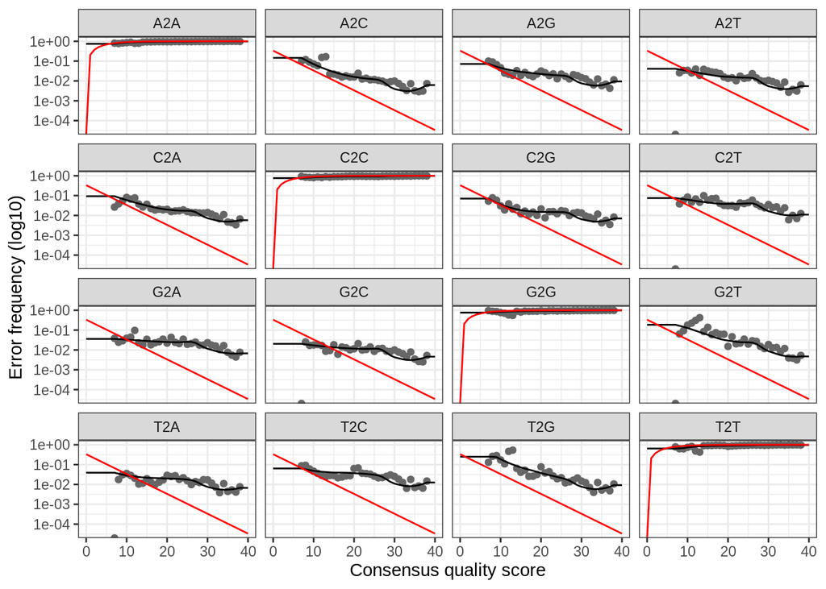

```r
plotErrors(errF, nominalQ=TRUE)
```

On applique l’algorithm d’inférence pour filtrer et trimmer les séquences!

```r
dadaFs <- dada(filtFs, err=errF, multithread=TRUE)
```

```
## Sample 1 - 4748 reads in 929 unique sequences.
## Sample 2 - 14704 reads in 4258 unique sequences.
## Sample 3 - 52282 reads in 23887 unique sequences.
## Sample 4 - 40587 reads in 22182 unique sequences.
## Sample 5 - 2311 reads in 614 unique sequences.
## Sample 6 - 6008 reads in 1488 unique sequences.
## Sample 7 - 58982 reads in 22237 unique sequences.
## Sample 8 - 39811 reads in 18943 unique sequences.
```

```r
dadaRs <- dada(filtRs, err=errR, multithread=TRUE)
```

```
## Sample 1 - 4748 reads in 964 unique sequences.
## Sample 2 - 14704 reads in 4413 unique sequences.
## Sample 3 - 52282 reads in 20194 unique sequences.
## Sample 4 - 40587 reads in 17692 unique sequences.
## Sample 5 - 2311 reads in 513 unique sequences.
## Sample 6 - 6008 reads in 1191 unique sequences.
## Sample 7 - 58982 reads in 17349 unique sequences.
## Sample 8 - 39811 reads in 15968 unique sequences.
```

```r
dadaFs[[1]]
```

```
## dada-class: object describing DADA2 denoising results
## 9 sequence variants were inferred from 929 input unique sequences.
## Key parameters: OMEGA_A = 1e-40, OMEGA_C = 1e-40, BAND_SIZE = 16
```

```r
mergers <- mergePairs(dadaFs, filtFs, dadaRs, filtRs)
```

On construit la table d’ASV. Les séquences trop longues ou trop courtes sont retirées car elles sont trés certainement issues d’appariemnet aspecifique!

```r
seqtab <- makeSequenceTable(mergers)
dim(seqtab)
```

```
## [1]    8 5656
```

```r
# Inspect distribution of sequence lengths
table(nchar(getSequences(seqtab)))
```

```
##
##  342  357  390  401  403  410  413  414  416  417  418  419  420  421  422  423
##    1    1    1    2    1    1    1    1    4   41  901  246  113   75   10  220
##  424  425  426  427  428  429  430  431  432  433  434  435  436  437  438  439
##   25   10    7    5   10   10   50    7   15   72   30   85   22   74  258   90
##  440  441  442  443  444  445  446  447  452  454  455  456  461  476  479  480
##   24   19  278 1436 1227  266    3    1    3    1    1    1    1    3    1    1
##  490
##    1
```

```r
#supprimer les séquences trop longues ou trop courtes
seqtab <- seqtab[,nchar(colnames(seqtab)) %in% 415:447]
```

On retire les séquences chimériques.

```r
seqtab.nochim <- removeBimeraDenovo(seqtab, method="consensus", multithread=TRUE)
dim(seqtab.nochim)
```

```
## [1]    8 3556
```

```r
sum(seqtab.nochim)/sum(seqtab)
```

```
## [1] 0.8689862
```

```r
seqtab <- seqtab.nochim
```

### Séquences suprimée par étapes

```r
getN <- function(x) sum(getUniques(x))
track <- cbind(out, sapply(dadaFs, getN), sapply(dadaRs, getN), sapply(mergers, getN), rowSums(seqtab.nochim))
# If processing a single sample, remove the sapply calls: e.g. replace sapply(dadaFs, getN) with getN(dadaFs)
colnames(track) <- c("input", "filtered", "denoisedF", "denoisedR", "merged", "nonchim")
rownames(track) <- sample.names
head(track)
```

```
##                        input filtered denoisedF denoisedR merged nonchim
## Lazar-CTRL-neg-PCR-bac  6194     4748      4742      4744   4742    4742
## P-152-bac              20096    14704     14499     14608  14101   14052
## P-153-bac              71526    52282     46512     49653  36360   29798
## P-154-bac              52582    40587     34699     37287  22322   20440
## P-156-bac               2963     2311      2249      2266   2173    2150
## P-157-bac               8466     6008      5865      5888   5786    5786
```

## IDTAXA Classification

On assigne la taxonomie aux **ASV** en utilisant **IDTAXA** nouvelle méthode de calssification [plus précise.](https://microbiomejournal.biomedcentral.com/articles/10.1186/s40168-018-0521-5)

On utilise la base de donnée **SILVA_SSU_v138** derniére version de SILVA téléchargée sur [DECIPHER](http://www2.decipher.codes/Downloads.html) pour étre sous forme d’objet R.

**threshold**: Indice de confiance de classfication conseil 60% (very high) ou 50 (high), plus les séquences sont longue plus ont peut augmenter l’indice de confiance car elle sont théoriquement plus facile a classifier.  
**processors = NULL**: scan et utilise tous les processeurs disponibles!

Les rang taxonomiques non identifié sont identifier comme `NA`

```r
dna <- Biostrings::DNAStringSet(getSequences(seqtab.nochim)) # Create a DNAStringSet from the ASVs
load("~/SILVA_SSU_r138_2019.RData") # CHANGE TO THE PATH OF YOUR TRAINING SET
ids <- IdTaxa(dna, trainingSet, strand="both", processors=NULL, verbose=FALSE, threshold = 50)
ranks <- c("domain", "phylum", "class", "order", "family", "genus", "species") # ranks of interest

# Convert the output object of class "Taxa" to a matrix analogous to the output from assignTaxonomy
taxid <- t(sapply(ids, function(x) {
        m <- match(ranks, x$rank)
        taxa <- x$taxon[m]
        taxa[startsWith(taxa, "unclassified_")] <- NA
        taxa
}))
colnames(taxid) <- ranks; rownames(taxid) <- getSequences(seqtab.nochim)
```

On retire les ASV non classifié comme apartenant au domaine bactérie dans le fichier tax. Puis dans la matrice d’ASV!

```r
taxid <-subset(as.data.frame(taxid), domain =="Bacteria")
seqtab <- seqtab[,colnames(seqtab) %in% rownames(taxid)]
```

Un témoin négatif est ajouté lors du séquençage afin d’observer la présence de contaminant du aux manipulations. Cependant retirer des autres écahntillons toutes les séquences présentes dans le temoin négatif n’est pas forcément idéal car les contamination croisée entre échantillons peuvent étre la premiére cause de contamination!

On observe la distribution des séquences présentent dans le temoin négatif avant de le supprimer!

```r
neg <- subset(as.data.frame(t(seqtab)), `Lazar-CTRL-neg-PCR-bac` != 0)
# VÉRIFIER LA DISTRIBUTION DES SÉQUENCES
seqtab <- seqtab[-c(1),-which(colnames(seqtab) %in% rownames(neg))] #supprimer les séquences du neg

# enregistrer le fichier tax
write.csv(as.data.frame(taxid), file = file.path(path,"ASV.tax.csv"))

#enregistrer la matrice d'ASV transposée pour éviter bug de chargement (trop de colones)
write.csv(as.data.frame(t(seqtab)),file = file.path(path,"ASV.matrice.t.csv"))
```

## Decipher allignement

Allignement des séquences

```r
library(DECIPHER)

seqs <- getSequences(seqtab)
names(seqs) <- seqs # This propagates to the tip labels of the tree
alignment <- AlignSeqs(DNAStringSet(seqs), anchor=NA)

#Enregistrer les séquences allignées en format FASTA
writeXStringSet(alignment, file = file.path(path,"ASV.align.fasta"),format="fasta")
```

## Fast Tree

Le Fasta aligné peut ensuite étre utilisé dans FAST TREE! Pour cela le `chunk` ci dessous doit étre un `bash`, ce script doit étre exécuté sur un serveur disposant de Fast tree.

```bash
fasttree -nt -gtr < ~/BacSeq/ASV.align.fasta > ~/BacSeq/tree
```

L’arbre créée n’est pas “rooted”. Donner des racines a un arbre signifie mentionner les ancétres commun et determiner leurs position. Les branches d’un arbres possédant des racines montre le moment exact de la séparation des espéces. La plupart des arbres n’estime pas la position des racines car cela demande un temps de calcul beaucoup plus important!

2 méthodes pour donner des racines a un arbre:  
**-Outgroup rooting**: Ajouter dans l’arbre des séquences connues. Le point auquel ces séquences rejoignes les autres devient la racine connue.  
**-Midpoint rooting**: On suppose que toutes les séquences évolues a la même vitesse.

[Qu’est ce qu’un arbre phylogénetique](https://www.ebi.ac.uk/training/online/course/introduction-phylogenetics/what-phylogeny/aspects-phylogenies/nodes)

On peut ajouter un “midpoint rooting”.

```r
library(phangorn)
Tree <- ape::read.tree(file = file.path(path,"tree"))
Tree.midpoint <- phangorn::midpoint(Tree)
ape::write.tree(Tree.midpoint,file = file.path(path,"tree.midpoint"))
```

## Attribuer un nom court aux ASV

On attribut un nom court aux ASV (ex: ASV18) à la place de la séquence compléte pour faciliter les prochaines analyses.

```r
library(phyloseq)
ps <- phyloseq(otu_table(t(seqtab), taxa_are_rows=TRUE), tax_table(as.matrix(taxid)))
taxa_names(ps) <- paste0("ASV", seq(ntaxa(ps)))

# enregistrer le fichier tax modifié (Short Name)
write.csv(as.data.frame(as(tax_table(ps), "matrix")), file = file.path(path,"ASV.tax.SN.csv"))

# enregistrer la matrice d'ASV transposé modifié (Short Name)
write.csv(as.data.frame(as(otu_table(ps), "matrix")),file = file.path(path,"ASV.matrice.SN.csv"))
```

## Raréfaction

**Supprimer les ASV non classifiés comme bactéries** **DADA2 ne permet pas de faire de raréfaction, utiliser `phyloseq::rarefy_even_depth`**